# Exploratory Sales Data Analysis & Visualization

Austin Oberg

3/25/2022

**This analysis is a simple look at tech sales dataset from the year 2019, provided by Knightbearr on Kaggle.com at the following link: https://www.kaggle.com/datasets/knightbearr/sales-product-data**

The goal of this analysis is to provide answers to the following questions:

**Q:** What was the best month for sales? How much was earned that month?

**Q:** What city had the highest number of sales?

**Q:** What product sold the most? Why do you think it sold the most?

**Q** Which produt yielded the highest revenue?

To complete this project, I utilized Google Sheets, BigQuery, and R Programming Language.

## Data aggregation and cleaning in SQL and Excel

The first step in processing this data was loading each month table into BigQuery and unioning them together. I exported this aggregated table from BigQuery into Google Sheets, where I used SPLIT and CONCATENATE to remove times from the column *Date*. I exported this as a .csv file and then repeated the process for the column *Purchase Address* to remove address number information. I uploaded both .csv files back into BigQuery to create new views for analysis and visualization. These views were saved as .csv files and loaded into R with read.csv(). From here I began answering questions.

## Analysis

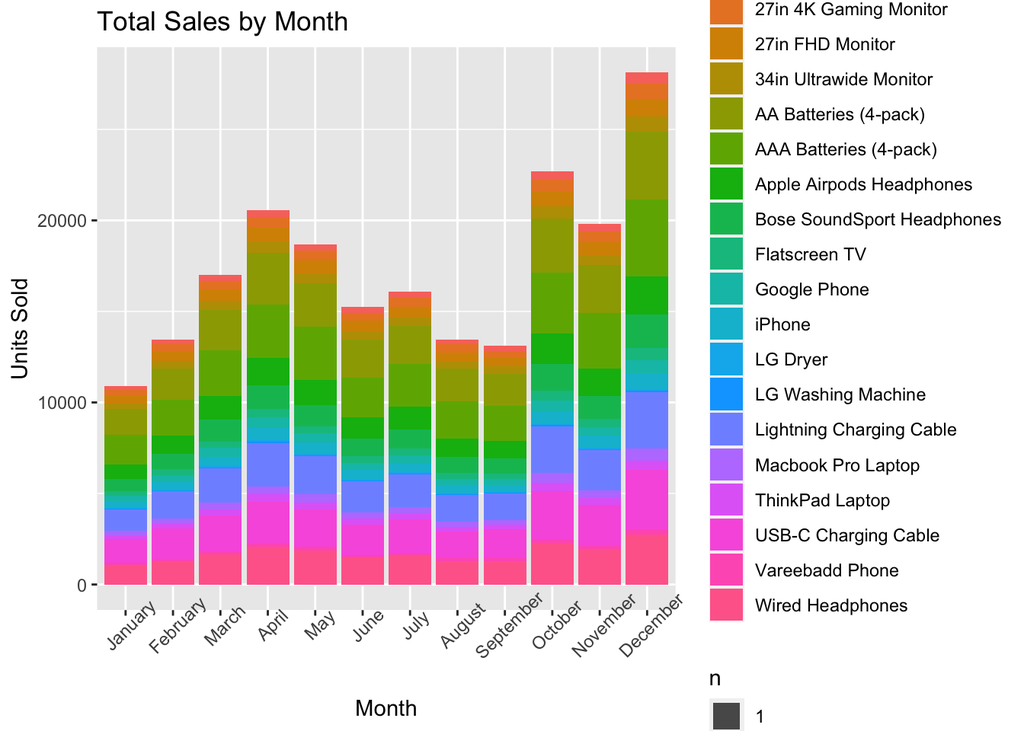

```r
ggplot(units_sold_mo %>%
         group_by(Date,Product) %>%
         summarize_at("Quantity_Sold", sum, na.rm=T),
       aes(Date, Quantity_Sold, fill = Product)) +
  geom_bar(stat="sum",na.rm=TRUE) +
  ggtitle("Total Sales by Month") +
  xlab("Month") + ylab("Units Sold") +
  theme(axis.text.x = element_text(angle = 45))
```

I started with a plot of Total Sales by Month. Looking at this gave me a clear answer to the first question. December had the highest number of sales in 2019. Using the following code chunk, I was able to ascertain that the amount of revenue from that month totaled was $4,569,702.

There may be a correlation between the number of sales and the time of year in which they occur. This possible relationship may be supported by the number of sales in December as compared to the rest of the year, due to the holidays. It may also be supported by April’s numbers, as there are Americans who receive tax refunds during the month of April.

```r
head(units_sold_mo %>%
         group_by(desc(Date)) %>%
        summarize_at("Revenue_Total", sum, na.rm=T))
```

```
## # A tibble: 6 × 2
##   `desc(Date)` Revenue_Total
##          <int>         <int>
## 1          -12       4569702
## 2          -11       3167467
## 3          -10       3700299
## 4           -9       2076254
## 5           -8       2221451
## 6           -7       2621867
```

Next, I looked at total sales by city.

```r
head((sales_cities %>%
  group_by(order_city) %>%
  summarize_at("Quantity_Ordered", sum)), 10)
```

```
## # A tibble: 10 × 2
##    order_city        Quantity_Ordered
##    <chr>                        <int>
##  1 Atlanta, GA                  16584
##  2 Austin, TX                   11137
##  3 Boston, MA                   22494
##  4 Dallas, TX                   16707
##  5 Los Angeles, CA              33247
##  6 New York City, NY            27903
##  7 Portland, ME                  2746
##  8 Portland, OR                 11291
##  9 San Francisco, CA            50169
## 10 Seattle, WA                  16534
```

```r
head((sales_cities %>%
  group_by(order_city) %>%
  summarize_at("Price_Each", sum)), 10)
```

```
## # A tibble: 10 × 2
##    order_city        Price_Each
##    <chr>                  <int>
##  1 Atlanta, GA          2767574
##  2 Austin, TX           1800993
##  3 Boston, MA           3619525
##  4 Dallas, TX           2738974
##  5 Los Angeles, CA      5395031
##  6 New York City, NY    4614337
##  7 Portland, ME          444929
##  8 Portland, OR         1852375
##  9 San Francisco, CA    8170654
## 10 Seattle, WA          2719615
```

```r
(8170654/(sum(sales_cities$Price_Each))) * 100
```

```
## [1] 23.94401
```

It looks like San Francisco has the highest number of sales at 50,169, with a total revenue of $8,170,654. This makes up 23.9% of the total revenue in 2019.